# rediMR_summary

2024-06-12

#### Check characteristics of diet PCs (derived without the diet trait)

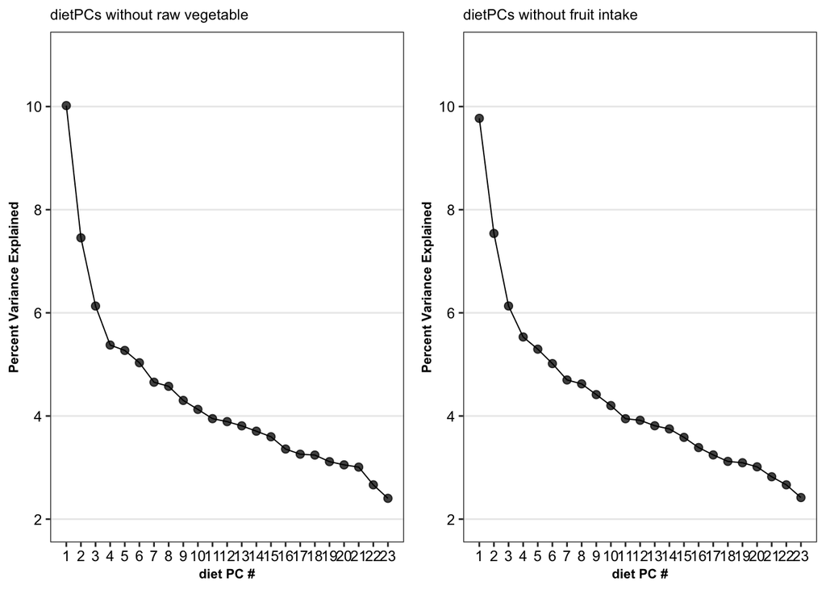

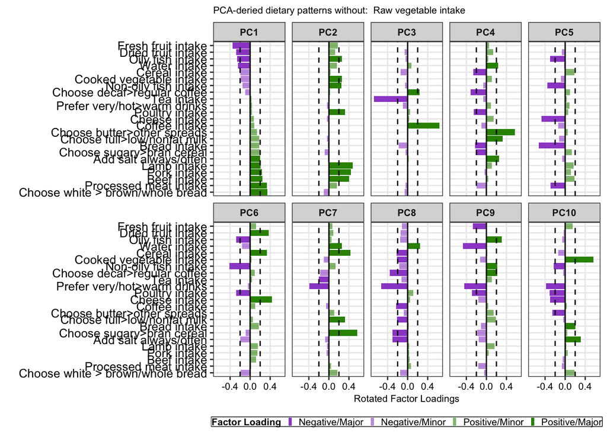

Checked assumptions: -Diet (specific traits & diet patterns) associate with behavioral, SES and biological confounders. -Phenotypic diet-confounder associations are attenuated, after adjusting for dietPCs

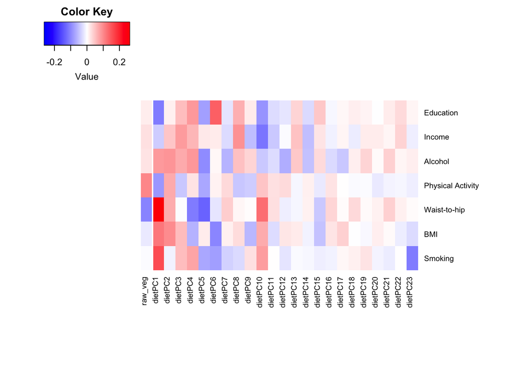

- Note: Not depicted, is an analyses of phenotypic correlations of diet-confounder associations: We saw that adjusting for dPCs attenuates the associations modestly, although not completely, suggesting there are unmeasured confounders or mediators.

### Examine the effect of diet PC adjustment on causal effect estimates for variant-Food intake associations

#### Examine the magnitude (%) change in Beta coefficients with dietPC adjustment

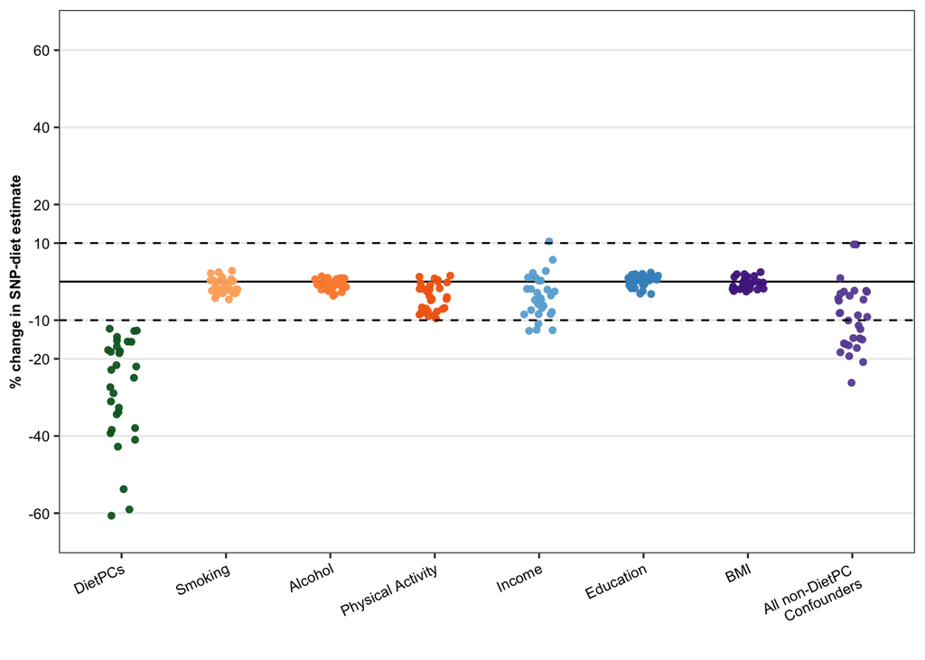

In the plots of magnitude (%) Beta change after adjusting for hypothesized confounders/mediators, we see most substantial impact on Betas when adjusting for INCOME relative to other behavioral/lifestyle traits.

##### Examine the adjusted Beta coefficients after dietPC adjustment

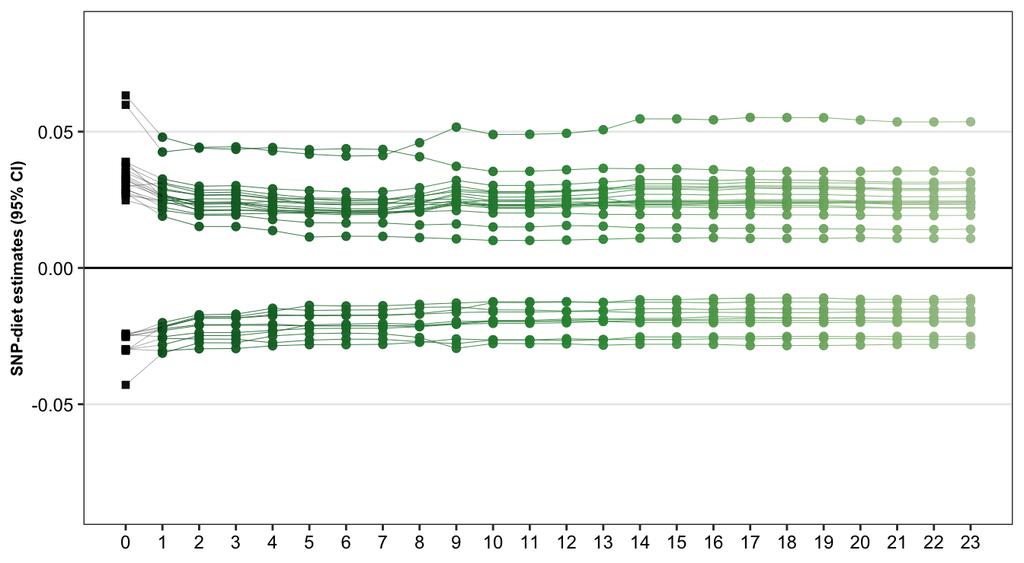

#### Focus on adjusted Beta coefficients for each confounder, in referent models either without (Base GWAS covariates) or with (DietPCs) prior adjustment for diet PCs

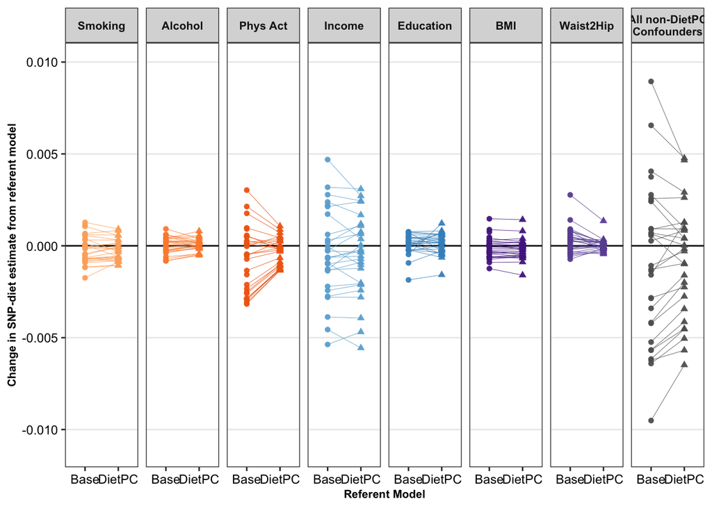

### Pull out individual SNP examples where hypothesis is supported and not

First, focus on Income associations given the apparent heterogeneity in variant-diet associations

```
## # A tibble: 27 × 14
##    snp     Covar B_pctChange_fromDiet B_pctChange   B_dPC   B_diff mod         B
##    <chr>   <fct>                <dbl>       <dbl>   <dbl>    <dbl> <chr>   <dbl>
##  1 rs1248… Diet…                -5.83       -42.8 -0.0152  8.85e-4 adj   -0.0143
##  2 rs4379… Diet…                -5.65       -32.9  0.0236 -1.33e-3 adj    0.0223
##  3 rs3486… Diet…                -5.38       -34.8  0.0234 -1.26e-3 adj    0.0221
##  4 rs2029… Diet…                -5.07       -28.7  0.0242 -1.23e-3 adj    0.0230
##  5 rs3131… Diet…                -4.68       -26.5  0.0221 -1.04e-3 adj    0.0211
##  6 rs3115… Diet…                -4.31       -25.0  0.0292 -1.26e-3 adj    0.0280
##  7 rs1145… Diet…                -4.27       -18.0  0.0310 -1.32e-3 adj    0.0297
##  8 rs5722… Diet…                -3.85       -30.1 -0.0184  7.09e-4 adj   -0.0177
##  9 rs9134… Diet…                -3.81       -36.9 -0.0281  1.07e-3 adj   -0.0271
## 10 rs3096… Diet…                -3.57       -15.3  0.0285 -1.02e-3 adj    0.0275
## # ℹ 17 more rows
## # ℹ 6 more variables: SE <dbl>, lowCI <dbl>, upCI <dbl>, P <dbl>,
## #   Reference_Model <chr>, Covar_cat <fct>
```

Then, expand to looking across all confounders

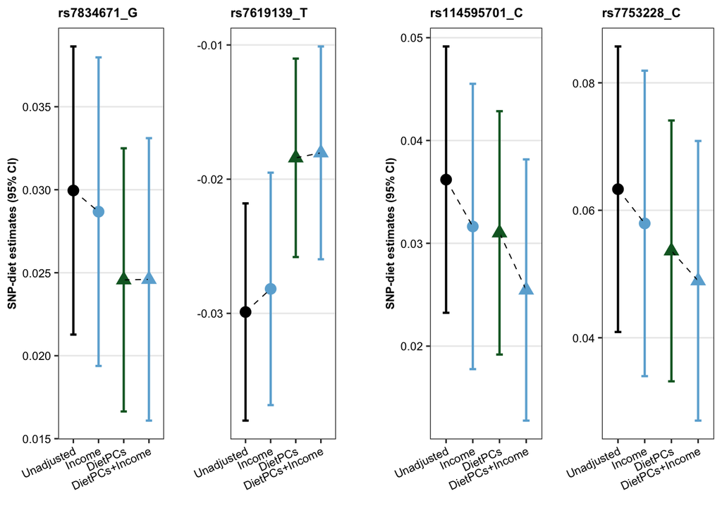

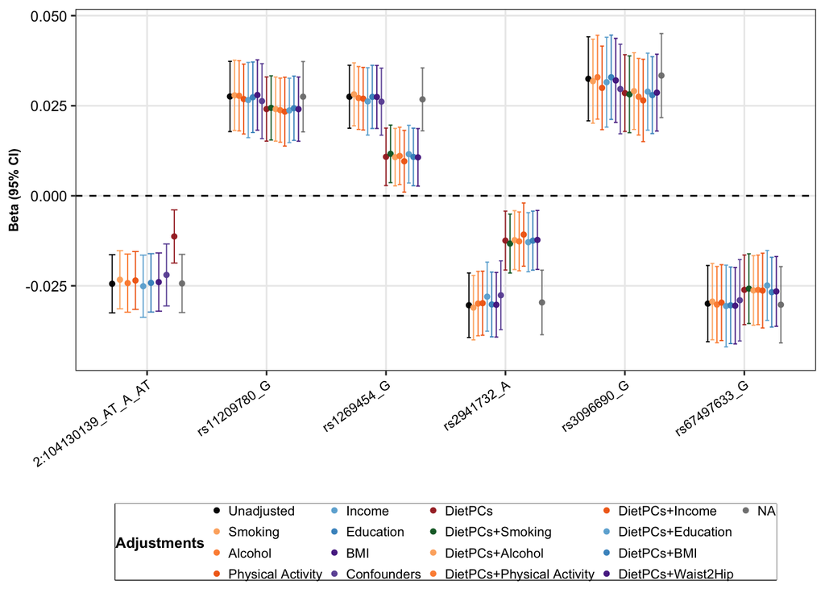

##### Summary:

- Note: adjusting for diet PCs attenuated all SNP-diet associations, but not to 0, indicating (1) remaining/unmeasured confounders/mediators explaining SNP-diet relations, or (2) possible direct effects of the SNP on diet, not explained by behavioral/lifestyle confounding or mediation.
- We then compared the effects of dPC adjustment to confounder adjusment. We hypothesized that adjusting for each confounder will attenuate the associations to a modest degree; and that adjusting for an appropriate amount of dPCs will attenuate the associations to a greater degree, representing correction for behaviora/lifestyle confounders.